# A Practical Introduction to Bayesian Modeling

### From Hypothesis to Model

So lets check in. We have explicitly stated our research question and hypotheses which we wish to test. We have also collected data in the form of daily survival checks and weather information which constitutes our know information. We have also broadly identified our unknown information which we wish to estimate. So the next step is to create our model, which is where we describe the relationship between our known and unknown data.

From here we are going to take a slight detour to just provide some context for how exactly we find estimates from this model, If you do not care to read about statistical theory (and who could blame you), you can just skip to where we discuss how to write probability statements describing our model (Writing Our Model Out).

#### Bayes Theorem

Very briefly, I want to touch on the statistical theory for why this works, which begins with looking at the **joint probability** of two occurrences happening. To understand this, we will need to use probability theory. We can approach our question by considering the joint probability of our data and $\theta$ occurring together, otherwise written as $P(y, \theta)$. This probability can be rederived using basic rules of conditional probability and written a number of different ways, as shown below…

$$P(y, \theta) = Pr(\theta|y)Pr(y) = Pr(y|\theta) Pr(\theta)$$

When we breakdown these probability statements, we find that the probability of both y and $\theta$ occurring together is the same as the probability of y occurring at all multiplied by the probability of $\theta$ occurring given that y also occurs (this can also be written with y and $\theta$ reversed). Using basic algebra, we can rearrange our equation to create the below statement, also referred to as Bayes Theorem.

$$Pr(\theta|y) = \frac{Pr(y|\theta) Pr(\theta)}{Pr(y)}$$
[Broad description]

#### Linking Theory and Information

[Uninformative priors] In the same way that a prior can represent our knowledge of a parameter, it can also be used to represent that we don’t have any prior knowledge of a system and adjust our estimates accordingly, [Benefits of this]

**Posterior Distribution** - [This is the most important quantity in Bayesian inference, goal of the analysis.] [Represents information about unknown parameters based on the data and priors provided.]

[Every posterior distribution used to be a prior]

#### Writing Our Model Out

Walk through the assumptions of the model and show how to code it.

we have an issue, survival is varying according to time-varying covariates, so the model need to reflect that. Coded differently than a non-time varying covariate.

[DISCUSS SUBSCRIPTS/INDEXING]

### MCMC: Sampling from the Posterior

[Bayesian Inference is just counting]

[Simulated draws from the posterior]

#### Markvoc Chain Monte Carlo Simulations

[Potential Sampling Approaches]

### Translating Model to Code: An Example in JAGS

#### MCMC Decisions

There are quite a few options that need to be made when you run a MCMC. These will largely influence model convergence/run time. [Broadly describe some decions.] The big issue many people run into when making these decisions which can slow them down is they are trying to find some correct answer, when in many cases these decisions are subject to the circumstances of the model, data, and researcher. So lets walk through some of these major questions.

**Starting Values** - [Where you tell the MCMC to begin sampling for a given parameter value can affect run time] [For a correctly specified model, this shouldn’t affect results]

[In certain instances, if you let the model choose its own starting values, it can results in impossible relationships, which will cause errors when you try to run the model. For example, if you accidentally supply a negative value to a distribution constrained above 0. By specifying a starting value, you allow the model to start in a realistic location]

[Also important to note, these programs hate NA values. So this may be another place where you need to supply starting information so there are no NA values]

**Burn-in Time** -

**Sampling Method** -

**Coding Language** - There are many ways that you can code and run an MCMC. We will focus on two coding frameworks that are currently most widely used among ecologists **JAGS** and **NIMBLE**. [BUGS language]. [Similarities]. [Differences]. [When to choose one of the other].

[Parallel Processing]

#### A JAGS Example

Translate our model into JAGS code

[Write model first, then worry about getting the data formatted correctly - Obviously make sure you aren’t writing a model that can’t use the data you have]

[Time varying covariate will require some cleverness]

#### Dynamic Indexing

https://mmeredith.net/blog/2021/JAGS_to_NIMBLE.htm

```r
JAGS.turkey.S.model <- function(){
  ###Priors
  base.S ~ dbeta(1,1)
  a.S <- logit(base.S)
  b.snow ~ dnorm(0, 1/1000)
  b.temp ~ dnorm(-1, 1/10)
  b.bc ~ dnorm(-1, 1/2)
  b.ag ~ dnorm(0, 1/1000)
  b.for ~ dnorm(0, 1/1000)


  ###LIKELIHOOD
  for(i in 1:n.ind){
    for(t in 1:n.days){
      logit(DSR[i,t]) <- a.S + b.snow*x.snow[t] + b.temp*x.temp[t] + b.bc*x.bc[i] + b.ag*x.ag[i] + b.for*x.for[i]
    }
  }

  for(j in 1:n.obs){
    obs.S[j] ~ dbern(period.S[j]) #Probability of survival since previous check
    period.S[j] <- prod(DSR[turkey.id[j], (day.found[j] - (1:days.since[j]))]) #Aggregrate survival across missed days
  }
}
```

[dnorm using precision instead of sd, common so important to note]

[Indexing to make these work is one of the more difficult things for me.]

[If something is in the equation (= or ~ or <-), then it either needs a prior (b.snow ~ dnorm(0, 1/1000)), be reference to supplied information (obs.S), or be described by estimated or supplied parameters (period.S[i,j] <- prod(DSR[i, missed.days[i,j]])) ]

Reformatting data to get what we want.

```r
#[Remove first column because don't care about time before]
obs.hist.mat.noDay1 <- obs.hist.mat[,-1]

#Doesn't like NAs, so we need to remove them from the observation history. An easy way to do this is to convert it to a vector
obs.hist.vec <- as.vector(t(obs.hist.mat.noDay1))
obs.hist <- obs.hist.vec[!is.na(obs.hist.vec)]


#Because of how we specified DSR within the model, we will need a way to reference between our observation and survival rate. We can create two vectors to reference which bird each observation references and which days to reference for a given time period

#First lets find the number of days between each observation
obs.days <- data.frame(which(!is.na(obs.hist.mat), arr.ind = T)) %>% #What day did an observation occur for each turkey
  rename(Turkey = row, ObsDay = col) %>%
  arrange(Turkey, ObsDay) %>% #Sort by turkey and day
  mutate(DaysSince = ifelse(ObsDay == 1, NA, ObsDay - lag(ObsDay))) #Make sure observations on day 1 don't count from previous bird.

turkey.id.mat <- day.found.mat <- days.since.mat <- matrix(NA, nrow = n.turkey, ncol = w.days+1)

for(i in 1:nrow(obs.days)){
  days.since.mat[obs.days$Turkey[i],obs.days$ObsDay[i]] <- obs.days$DaysSince[i]
}
days.since.vec <- as.vector(t(days.since.mat))
days.since <- days.since.vec[!is.na(days.since.vec)]

#Finally we will need a vector to reference which day a observation occurred on and a separate vector describing which turkey
for(t in 2:(1+w.days)){
  day.found.mat[, t] <- t
}
day.found.mat <- day.found.mat[,-1]
day.found.vec <- as.vector(t(day.found.mat))
day.found <- day.found.vec[!is.na(obs.hist.vec)]

for(i in 1:n.turkey){
  turkey.id.mat[i,] <- i
}
turkey.id.mat <- turkey.id.mat[,-1]
turkey.id.vec <- as.vector(t(turkey.id.mat))
turkey.id <- turkey.id.vec[!is.na(obs.hist.vec)]
```

```r
#Data to supply to the model
data.list <- list(
  #Observation Information
  obs.S = obs.hist, #Vector containing observed survival history
  days.since = days.since, #Vector describing number of days since previous observation
  day.found = day.found, #Vector describing which day an observation occurred
  turkey.id = turkey.id, #Vector describing which turkey an observation was for
  n.ind = nrow(turkey.sim), #Number of individual turkeys monitored
  n.days = ncol(weather.sim), #Number of days in history
  n.obs = length(obs.hist), #Number of total observations

  #Covariate Information
  x.snow = weather.sim[1,], #Vector describing snow depth on a given day
  x.temp = weather.sim[2,], #Vector describing temperature on a given day
  x.bc = turkey.sim[,1], #Vector describing body condition for a given turkey
  x.ag = turkey.sim[,2], #Vector describing whether a turkey primarily uses agriculture landscape
  x.for = turkey.sim[,3] #Vector describing whether a turkey primarily uses forested landscape
)

#Parameter Monitors
parameters.null <-c(
  #Regression Coefficients
  "a.S",
  "b.snow",
  "b.temp",
  "b.bc",
  "b.ag",
  "b.for"
)

#Initial Values
inits.null <- function(){
  list(
    base.S = .998 #Set initial value for base survival rate
  )
}
```

#### Considerations for Run Time

One of the biggest goals of MCMC analysis is to have the model converge as quickly as possible. This helps to save time… There will be many factors affecting run time and many decisions you can make to reduce it.

**Number of parameters to estimate** - [More nodes means more combinations means more simulations?]

**Iterations** - [Longer simulations = bigger sample size esentially]

**Burn In Period** - [Model needs time to find a stable equilibrium]

**Thinning** - [Initially used to help with autocorrelation, but arguments against thinning…wasted data]

**Number of Chains** -

**Parallel Processing** -

**Initial Values** - [Starting Closer to posterior maximum can aid in convergence]

[These decisions will be consistent across coding options, although implimentation may differ.]

#### Running the Model

```r
#Make final MCMC related decisions
ni <- 2000 #Number of simulations to run
nb <- 1000 #Length of burnin in period
nt <- 1 #How much thinning should there be
nc <- 3 #Number of chains to run simultaneously

#Run the model
Surv_JAGS_output <- jags(data = data.list,
                        parameters.to.save = parameters.null,
                        inits = inits.null,
                        model.file = JAGS.turkey.S.model,
                        n.iter = ni,
                        n.burnin = nb,
                        n.thin = nt,
                        n.chains = nc)
```

```
## module glm loaded
```

#### Common Errors

[Heather Gaya GitHub](https://github.com/heathergaya/JAGS-NIMBLE-Tutorials/tree/master/JAGS_Errors)

#### Model Diagnostics and Reporting Results (JAGS)

[Different components of the output object]

[Trace Plots]

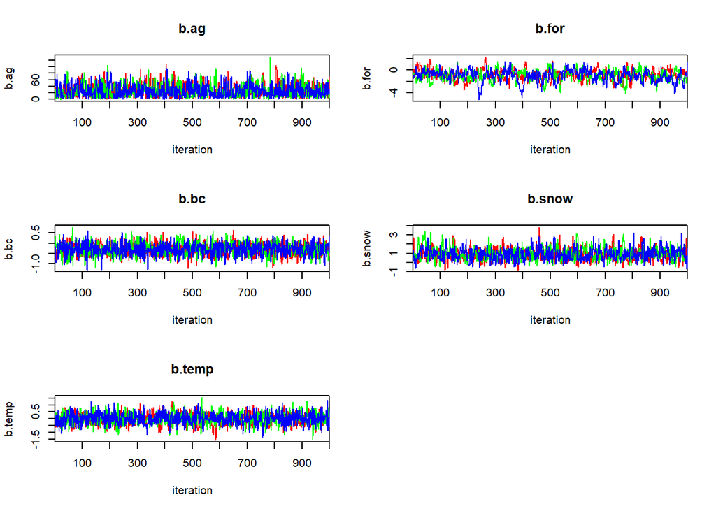

```r
traceplot(Surv_JAGS_output, #bugs output object
          mfrow = c(3,2), #Rows and Columns in figure
          ask = F, #Ask before plotting?
          varname = c("b.ag", "b.for", "b.bc", "b.snow", "b.temp")) #Which parameters to plot
```

```r
#Basic Parameter Estimates
print(Surv_JAGS_output)
```

```
## Inference for Bugs model at "C:/Users/mgonn/AppData/Local/Temp/RtmpWIoUKf/model6514ed6572f.txt", fit using jags,
##  3 chains, each with 2000 iterations (first 1000 discarded)
##  n.sims = 3000 iterations saved
##          mu.vect sd.vect   2.5%    25%    50%    75%  97.5%  Rhat n.eff
## a.S        7.834   0.926  6.317  7.184  7.729  8.361  9.900 1.013   160
## b.ag      26.466  19.827  1.703 10.975 22.097 37.670 72.507 1.002  1400
## b.bc      -0.291   0.300 -0.869 -0.495 -0.286 -0.084  0.296 1.003   990
## b.for     -0.938   0.974 -2.968 -1.536 -0.882 -0.281  0.862 1.010   280
## b.snow     0.927   0.661 -0.198  0.457  0.873  1.332  2.450 1.005   430
## b.temp     0.009   0.419 -0.814 -0.270  0.006  0.283  0.838 1.001  2100
## deviance  75.862   2.940 71.981 73.706 75.225 77.445 82.918 1.002  1500
##
## For each parameter, n.eff is a crude measure of effective sample size,
## and Rhat is the potential scale reduction factor (at convergence, Rhat=1).
##
## DIC info (using the rule, pD = var(deviance)/2)
## pD = 4.3 and DIC = 80.2
## DIC is an estimate of expected predictive error (lower deviance is better).
```

If we want to run a more in-depth diagnostics of our model, it can be useful to extract the actual MCMC chains. This allows for the running of various diagnostic functions.

```r
#Convert BUGS output into MCMC for further information and plotting options
Surv_JAGS_MCMC <- as.mcmc(Surv_JAGS_output)
summary(Surv_JAGS_MCMC)
```

```
##
## Iterations = 1001:2000
## Thinning interval = 1
## Number of chains = 3
## Sample size per chain = 1000
##
## 1. Empirical mean and standard deviation for each variable,
##    plus standard error of the mean:
##
##               Mean      SD Naive SE Time-series SE
## a.S       7.833856  0.9257 0.016901       0.057336
## b.ag     26.466087 19.8270 0.361990       0.609022
## b.bc     -0.290589  0.2997 0.005471       0.007597
## b.for    -0.938011  0.9743 0.017787       0.049715
## b.snow    0.927242  0.6612 0.012071       0.022712
## b.temp    0.009086  0.4192 0.007653       0.010040
## deviance 75.862097  2.9399 0.053674       0.094213
##
## 2. Quantiles for each variable:
##
##             2.5%     25%       50%      75%   97.5%
## a.S       6.3175  7.1835  7.729401  8.36146  9.9001
## b.ag      1.7030 10.9755 22.097300 37.66959 72.5070
## b.bc     -0.8692 -0.4949 -0.285978 -0.08379  0.2963
## b.for    -2.9684 -1.5356 -0.881936 -0.28118  0.8615
## b.snow   -0.1982  0.4571  0.873137  1.33209  2.4502
## b.temp   -0.8138 -0.2698  0.006217  0.28254  0.8382
## deviance 71.9814 73.7064 75.225454 77.44457 82.9183
```

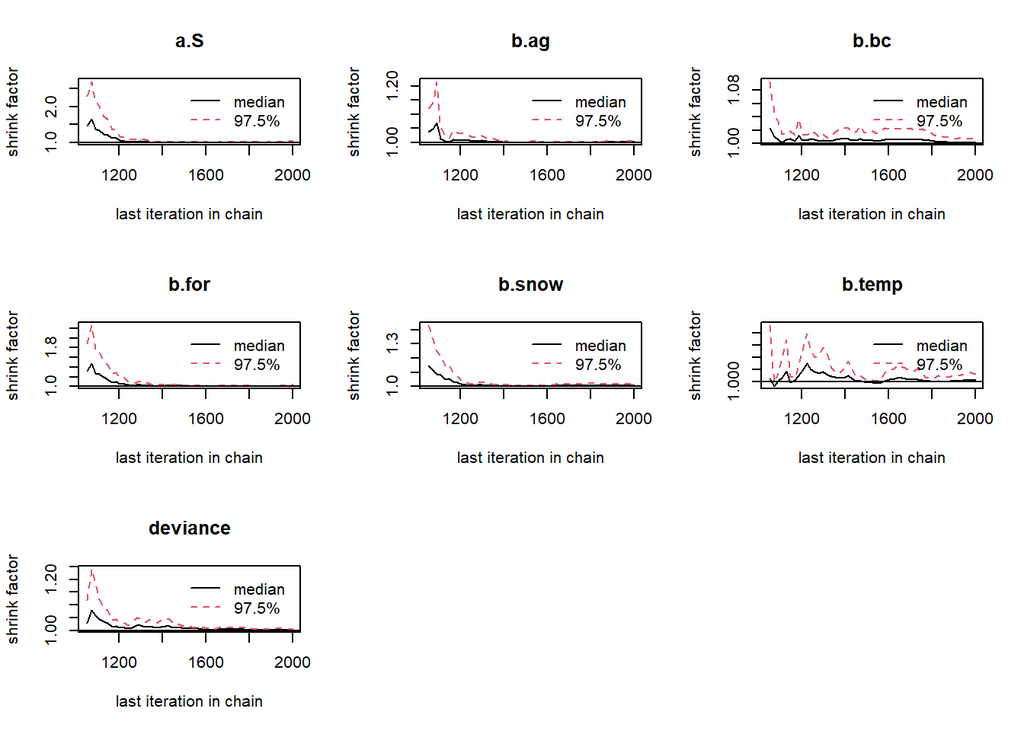

```r
require(coda)
gelman.plot(Surv_JAGS_MCMC)
```

```r
heidel.diag(Surv_JAGS_MCMC)
```

```
## [[1]]
##
##          Stationarity start     p-value
##          test         iteration
## a.S      passed       1         0.564
## b.ag     passed       1         0.877
## b.bc     passed       1         0.748
## b.for    passed       1         0.470
## b.snow   passed       1         0.688
## b.temp   passed       1         0.850
## deviance passed       1         0.107
##
##          Halfwidth Mean     Halfwidth
##          test
## a.S      passed     7.69149 0.1662
## b.ag     passed    27.39746 2.2937
## b.bc     passed    -0.28154 0.0240
## b.for    failed    -0.82644 0.1512
## b.snow   passed     0.86691 0.0655
## b.temp   failed    -0.00877 0.0325
## deviance passed    75.98212 0.3564
##
## [[2]]
##
##          Stationarity start     p-value
##          test         iteration
## a.S      passed       1         0.945
## b.ag     passed       1         0.784
## b.bc     passed       1         0.340
## b.for    passed       1         0.929
## b.snow   passed       1         0.644
## b.temp   passed       1         0.296
## deviance passed       1         0.530
##
##          Halfwidth Mean    Halfwidth
##          test
## a.S      passed     7.8816 0.2029
## b.ag     passed    25.5744 2.1180
## b.bc     passed    -0.2805 0.0278
## b.for    failed    -0.9653 0.1476
```

[output cut: 10 more lines]

```
## b.bc     passed       1         0.309
## b.for    passed       1         0.183
## b.snow   passed       1         0.499
## b.temp   passed       1         0.901
## deviance passed       1         0.175
##
##          Halfwidth Mean    Halfwidth
##          test
## a.S      passed     7.9285 0.2118
## b.ag     passed    26.4264 1.7541
## b.bc     passed    -0.3097 0.0255
## b.for    failed    -1.0222 0.2020
## b.snow   passed     0.9389 0.0736
## b.temp   failed     0.0215 0.0353
## deviance passed    75.8839 0.2982
```

#### Failure to Converge

[Before rewriting your model, it may be worth first adjusting MCMC options] [Interations/BurnIn time] [Starting Values]

https://cran.r-project.org/web/packages/EcoDiet/vignettes/convergence_problems.html

[Using the original MCMC run to continue simulations with the same model]

```r
Surv_JAGS_update <- update(Surv_JAGS_output, n.iter = 1000) #Continues the same simulation, adding iterations
Surv_JAGS_update <- autojags(Surv_JAGS_output) #Automatically updates model until convergence
```

#### Evaluating and Presenting Results

[Posterior Distribution]

### A Bayesian Alternative: NIMBLE

[Same thing, but in nimble. Will skim over the theoretical and practical implications of our decisions and just show how to code them. ] [Why use NIMBLE over JAGS]

[Very quickly show how easily this could be coded using RMark or whatever].

So you may be thinking, “if its so easy to do this using a frequentist framework, why in the world did you make me do this long exercise?!.”

#### Direct Comparisons

**Intuitive Description of Uncertainty** - [Hypothetical Replicates vs Probability Statements]

[So now that you know how to do this under a bayesian framework, and you’ve seen how complicated it is, how would we run the same analysis as a frequentist?]

### A Frequentist Alternative: RMark

[Phidot link](http://www.phidot.org/software/mark/docs/book/pdf/chap17.pdf)

#### Format the Data

```r
EH.rmark <- as.data.frame(obs.hist.mat)[-1,] %>%
  mutate(TurkID = row_number()) %>%
  rowwise() %>%
  mutate(FirstFound = 1, #Conveniently, all of our simulated birds were caught on the same day
         LastPresent = max(which(c_across(1:(w.days)) == 1)), #When was the turkey last observed alive
         LastChecked = max(which(!is.na(c_across(1:(w.days))))), #When was the turkey first observed dead
         Fate = min(c_across(everything()), na.rm = T), #What was the final known fate of a bird through the period of itnerest?
         Freq = 1) %>% #Number of repetitions of a given encounter history, I don't usually aggregate
  mutate(LastChecked = ifelse(Fate == 1, w.days + 1, LastChecked)) %>%
  # mutate(LastChecked = ifelse(FirstDead > LastAlive)) %>%
  dplyr::select(TurkID,
                FirstFound,
                LastPresent,
                LastChecked,
                Fate,
                Freq)

indcov.rmark <- as.data.frame(turkey.sim) %>%
  rename(BC = V1, Ag = V2, For = V3) %>%
  mutate(TurkID = row_number(),
         Ag = as.factor(Ag), #RMark will convert automatically, but can preemptively do this to avoid messages
         For = as.factor(For))

data.rmark <- merge(EH.rmark, indcov.rmark)

WintSurv.process = process.data(data.rmark,
                               model="Nest", #We will run this in a nest survival framework
                               nocc=w.days + 1, #Number of occassions in the EH
                               groups=c("Ag", "For")) #Identify categorical covariates here
WintSurv.ddl = make.design.data(WintSurv.process)


## Add Daily Weather data to design data
weather.cov<- data.frame(seq(1,w.days,1))
colnames(weather.cov)<- c("time")
weather.cov$Snow<- weather.sim[1,]
weather.cov$Temp<- weather.sim[2,]

WintSurv.ddl$S=merge_design.covariates(WintSurv.ddl$S,weather.cov,bygroup=FALSE, bytime=TRUE)
```

####Run the model and compare

```r
require(RMark)
RMark.model <- mark(WintSurv.process,
                    WintSurv.ddl,
                    model.parameters=list(S=list(formula =~ BC + Ag + For + Snow + Temp,
                                                 link="logit")))
```

```
##
## Output summary for Nest model
## Name : S(~BC + Ag + For + Snow + Temp)
##
## Npar :  6
## -2lnL:  1530.588
## AICc :  1542.603
##
## Beta
##                    estimate        se        lcl        ucl
## S:(Intercept)  3.842728e+00 0.1517985  3.5452028  4.1402529
## S:BC          -7.183848e-06 0.0523496 -0.1026123  0.1025980
## S:Ag1          4.928186e-04 0.1820789 -0.3563818  0.3573674
## S:For1         5.630993e-04 0.1812006 -0.3545901  0.3557163
## S:Snow        -1.563986e-01 0.0745278 -0.3024731 -0.0103240
## S:Temp         1.062962e+00 0.0977988  0.8712762  1.2546475
##
##
## Real Parameter S
##                        1         2         3         4         5         6
## Group:Ag0.For0 0.9159629 0.9956337 0.9867064 0.9177859 0.9716118 0.9518469
## Group:Ag1.For0 0.9160008 0.9956359 0.9867129 0.9178231 0.9716254 0.9518695
## Group:Ag0.For1 0.9160062 0.9956362 0.9867138 0.9178284 0.9716273 0.9518727
##                        7         8         9        10        11        12
## Group:Ag0.For0 0.9895272 0.9012612 0.9750598 0.9942963 0.8885395 0.9605796
## Group:Ag1.For0 0.9895323 0.9013050 0.9750718 0.9942991 0.8885883 0.9605983
## Group:Ag0.For1 0.9895331 0.9013113 0.9750735 0.9942995 0.8885953 0.9606009
##                       13        14        15        16        17        18
## Group:Ag0.For0 0.9862924 0.9956756 0.9912767 0.9813617 0.9903858 0.9958965
## Group:Ag1.For0 0.9862991 0.9956777 0.9912809 0.9813707 0.9903905 0.9958985
## Group:Ag0.For1 0.9863001 0.9956780 0.9912815 0.9813720 0.9903912 0.9958988
##                       19        20        21        22        23        24
## Group:Ag0.For0 0.9049804 0.9862143 0.9939163 0.9876275 0.9447544 0.9520593
## Group:Ag1.For0 0.9050227 0.9862210 0.9939193 0.9876335 0.9447801 0.9520818
## Group:Ag0.For1 0.9050288 0.9862219 0.9939197 0.9876343 0.9447838 0.9520850
##                       25        26        27        28        29        30
## Group:Ag0.For0 0.9622726 0.9816466 0.9733436 0.9780882 0.9958077 0.9488224
## Group:Ag1.For0 0.9622905 0.9816555 0.9733564 0.9780988 0.9958098 0.9488463
## Group:Ag0.For1 0.9622931 0.9816568 0.9733582 0.9781003 0.9958101 0.9488497
```

```r
summary(RMark.model)
```

```
## Output summary for Nest model
## Name : S(~BC + Ag + For + Snow + Temp)
##
## Npar :  6
## -2lnL:  1530.588
## AICc :  1542.603
##
## Beta
##                    estimate        se        lcl        ucl
## S:(Intercept)  3.842728e+00 0.1517985  3.5452028  4.1402529
## S:BC          -7.183848e-06 0.0523496 -0.1026123  0.1025980
## S:Ag1          4.928186e-04 0.1820789 -0.3563818  0.3573674
## S:For1         5.630993e-04 0.1812006 -0.3545901  0.3557163
## S:Snow        -1.563986e-01 0.0745278 -0.3024731 -0.0103240
## S:Temp         1.062962e+00 0.0977988  0.8712762  1.2546475
##
##
## Real Parameter S
##                        1         2         3         4         5         6
## Group:Ag0.For0 0.9159629 0.9956337 0.9867064 0.9177859 0.9716118 0.9518469
## Group:Ag1.For0 0.9160008 0.9956359 0.9867129 0.9178231 0.9716254 0.9518695
## Group:Ag0.For1 0.9160062 0.9956362 0.9867138 0.9178284 0.9716273 0.9518727
##                        7         8         9        10        11        12
## Group:Ag0.For0 0.9895272 0.9012612 0.9750598 0.9942963 0.8885395 0.9605796
## Group:Ag1.For0 0.9895323 0.9013050 0.9750718 0.9942991 0.8885883 0.9605983
## Group:Ag0.For1 0.9895331 0.9013113 0.9750735 0.9942995 0.8885953 0.9606009
##                       13        14        15        16        17        18
## Group:Ag0.For0 0.9862924 0.9956756 0.9912767 0.9813617 0.9903858 0.9958965
## Group:Ag1.For0 0.9862991 0.9956777 0.9912809 0.9813707 0.9903905 0.9958985
## Group:Ag0.For1 0.9863001 0.9956780 0.9912815 0.9813720 0.9903912 0.9958988
##                       19        20        21        22        23        24
## Group:Ag0.For0 0.9049804 0.9862143 0.9939163 0.9876275 0.9447544 0.9520593
## Group:Ag1.For0 0.9050227 0.9862210 0.9939193 0.9876335 0.9447801 0.9520818
## Group:Ag0.For1 0.9050288 0.9862219 0.9939197 0.9876343 0.9447838 0.9520850
##                       25        26        27        28        29        30
## Group:Ag0.For0 0.9622726 0.9816466 0.9733436 0.9780882 0.9958077 0.9488224
## Group:Ag1.For0 0.9622905 0.9816555 0.9733564 0.9780988 0.9958098 0.9488463
## Group:Ag0.For1 0.9622931 0.9816568 0.9733582 0.9781003 0.9958101 0.9488497
```

### Comparing Bayesian and Frequentist Approaches

**Randomness vs Uncertainty** - [Randomness (frequentist) vs uncertainty (Bayesian) - Nothing is actually random, if we had enough information and a powerful enough computer, you could predict almost any natural system in theory]

[Kery and Schaub - Bayesian pop analysis ch 2.4]

[Held and Bove - Likelihood and Bayesian Inference ch 3]

[Hobbs and Hooten - 4.2 Likelihood profiles]

### Sources and Other Resources

This module is a synthesis of ideas and code found in…

[Dan Gibson’s Nest Survival Code](https://dan-gibson.weebly.com/nest-survival-jags.html)  
Hobbs and Hooten - Bayesian Models: A Statistical primer for Ecologists  
McElreath - Statistical Rethinking: A Bayesian Course with Examples in R and Stan  
Kery - Introduction to WinBUGS for Ecologists: A Bayesian approach to regression, ANOVA, mixed models and related analyses  
Kery and Schaub - Bayesian Population Analysis using WinBUGS: A Hierarchical Perspective

I have also found the below resources useful in familiarizing myself with and better understanding bayesian concepts and applications.

[Olivier Giminez’s Youtube Channel](https://www.youtube.com/c/OlivierGimenez)  
[Richard McElreath’s Youtube Channel](https://www.youtube.com/channel/UCNJK6_DZvcMqNSzQdEkzvzA/about)  
[ritvikmath Youtube Channel](https://www.youtube.com/c/ritvikmath)  
[Fox 2011 - Frequentist vs. Bayesian statistics: resources to help you choose](https://dynamicecology.wordpress.com/2011/10/11/frequentist-vs-bayesian-statistics-resources-to-help-you-choose/)  
[McGill 2013 - Why saying you are a bayesian is a low information statement](https://dynamicecology.wordpress.com/2013/06/19/why-saying-you-are-a-bayesian-is-a-low-information-statement/)  
[rasmusab Youtube Channel](https://www.youtube.com/channel/UCO7kJ__JJ4v4RQU3ZymR3Kw)